# The Bermuda Atlantic Time-series Study (BATS)

Jenniffer Perez

2023-04-10

**1. Introduction:**

The Bermuda Atlantic Time-series Study (BATS) history was created to answer scientific questions to study oceanography problems. Some of these questions addressed how the ocean reacts to global climate change, and how does the ecosystem balances. All these questions were answered through an in-depth data analysis for data collection over a long period of time. The program first started in 1954, when Dr. Henry M. Stommel initiated a deep-water research monitoring known as the Hydrostation `S` to acquired information of the ocean. Some of the data collected included temperature, salinity and dissolved oxygen measurements. Eventually, the program was linked to BIOS and the U.S. Joint Global Ocean Flux Study program that started in 1988. BATS was designed to study the ocean and analyze important hydrographic and biological parameters through the water column. With the data available to scientist and oceanographers can be used to study the ocean physical, chemical and biological processes and uncover new observations about the ocean. BATS DATA can also help understand better the chemical cycle such as the active carbon transport and the biological Carbon Pump. The BATS data continues to be available worldwide and integrates new technology with methods to approach new ocean innovations. The = BATS data was used to adress the following questions: Is surface ocean pCO2 increasing? Is surface ocean seawater pH decreasing? Is surface ocean seawater saturation state with respect to aragonite decreasing?

BATS data Variables available:

#yyyymmdd = Year Month Day  
#decy = Decimal Year  
#time = Time (hhmm)  
#latN = Latitude (Deg N) #lonW = Longitude (Deg W) #Depth = Depth (m)  
#Temp = Temperature ITS-90 (C)  
#CTD_S = CTD Salinity (PSS-78)  
#Sal1 = Salinity-1 (PSS-78)  
#Sig-th = Sigma-Theta (kg/m^3)  
#O2(1) = Oxygen-1 (umol/kg)  
#OxFixT = Oxygen Fix Temp (C)  
#Anom1 = Oxy Anomaly-1 (umol/kg)  
#CO2 = dissolved inorganic carbon (umol/kg)  
#Alk = Alkalinity (uequiv)  
#NO31 = Nitrate+Nitrite-1 (umol/kg) #NO21 = Nitrite-1 (umol/kg)  
#PO41 = Phosphate-1 (umol/kg)  
#Si1 = Silicate-1 (umol/kg)  
#POC = POC (ug/kg)  
#PON = PON (ug/kg)  
#TOC = TOC (umol/kg)  
#TN = TN (umol/kg)  
#Bact = Bacteria enumeration (cells*10^8/kg)  
#POP = POP (umol/kg) #TDP = Total dissolved Phosphorus (nmol/kg) #SRP = Low-level phosphorus (nmol/kg) #BSi = Particulate biogenic silica (umol/kg) #LSi = Particulate lithogenic silica (umol/kg) #Pro = Prochlorococcus (cells/ml) #Syn = Synechococcus (cells/ml) #Piceu = Picoeukaryotes (cells/ml) #Naneu = Nanoeukaryotes (cells/ml)

**2. Methods:**

**3. Results:**

```
3.1. Data import:
```

```r
# Step 1: Data imported from BATS

bats_bottle <- read_delim("bats_bottle.txt",
                          delim = "\t",
                          escape_double = FALSE,
                          col_names = FALSE, trim_ws = TRUE, skip = 60)

# Import column names from BATS and assign to Data
colnames(bats_bottle) <- colnames(read_csv("bats_bottle.txt", skip = 59))

# View the imported BATS data
View(bats_bottle)
```

**CO2 Chemestry Parameters** pCO2 ?carb

```r
#We have TA, DIC, S, T, Pt, Sit, but we don't have pressure

#Step 1:  First we need to calculate pressure (dbar) using TEOS-10:
?gsw
```

```
## starting httpd help server ... done
```

```r
#p = gsw_p_from_z(z,lat)
bats_co2=bats_bottle %>%
  mutate(P_dbar=gsw_p_from_z(Depth*-1,latN))
View(bats_co2)

#We now have all of the variables that we need to calculate the surface seawater chemistry at the BATS station, but that we need to be very careful about our units!
#We now have TA, DIC, S, T, Pt, Sit, Pressure
#What are the units of these and what does CO2SYS need?

#TA is in uequiv (umol/kg) and we need mol/kg
# Alk*10^-6

#DIC is in umol/kg and we need mol/kg
# CO2*10^-6

#S is in PSS and we will use EOS80
# Sal1

#T is in degrees C and we need degrees C
# Temp

#Pt is in umol/kg and we need mol/kg
# PO41*10^-6

#SiT is in umol/kg and we need mol/kg
# Si1*10^-6

#P_dbar is in dbar and we need bar
# P_dbar/10 OR P_dbar*10^-1
# #We will need to convert units scaling when using CO2SYS
#flag = 15 ALK and DIC given
?carb

bats_co2sys=
  bats_co2 %>%
  filter(Alk!=-999,CO2!=-999,Sal1!=-999,Temp!=-999,
         P_dbar!=-999,PO41!=-999,Si1!=-999,
         lonW!=-999,latN!=-999)%>%
  rename(DIC=CO2) %>%
  mutate(carb(flag=15, var1=Alk*10^-6, var2=DIC*10^-6,
              S=Sal1, T=Temp, Patm=1, P=P_dbar*10^-1,
              Pt=PO41*10^-6, Sit=Si1*10^-6,
              k1k2="l", kf="pf", ks="d", pHscale="T",
              b="u74", gas="potential",
              warn="y", eos="eos80",long=360-lonW, lat=latN))
```

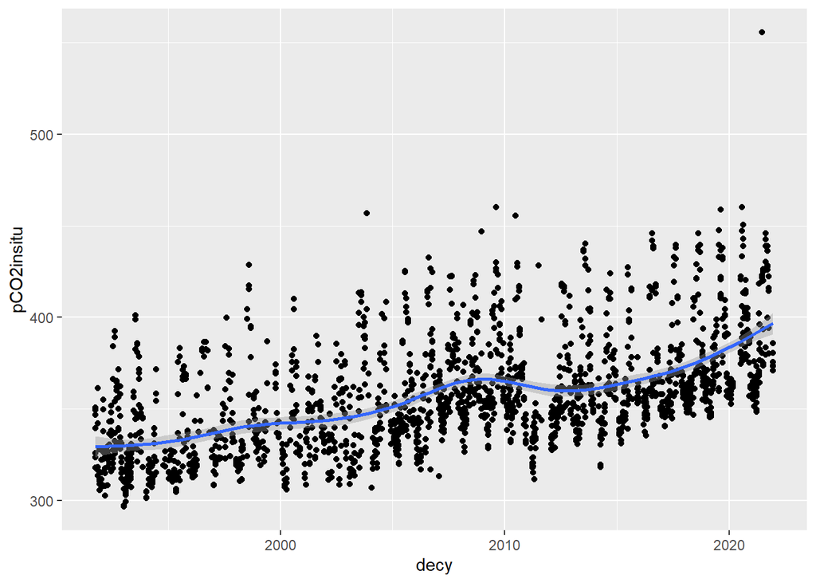

```r
bats_co2sys_surf = bats_co2sys %>%
  filter(Depth<100) %>%  #we are selecting only the upper 100m
  filter(pCO2insitu>100)


bats_co2sys_surf %>%
  ggplot(mapping=aes(x=decy,y=pCO2insitu))+
  geom_point()+
  geom_smooth()
```

```r
check=bats_co2sys_surf %>%
  filter(pCO2<200)

pco2_model = lm(pCO2insitu~decy,data=bats_co2sys_surf)
summary(pco2_model)
```

```
##
## Call:
## lm(formula = pCO2insitu ~ decy, data = bats_co2sys_surf)
##
## Residuals:
##     Min      1Q  Median      3Q     Max
## -52.302 -18.081  -7.098  12.657 173.045
##
## Coefficients:
##               Estimate Std. Error t value Pr(>|t|)
## (Intercept) -3.396e+03  1.328e+02  -25.57   <2e-16 ***
## decy         1.869e+00  6.616e-02   28.25   <2e-16 ***
## ---
## Signif. codes:  0 '***' 0.001 '**' 0.01 '*' 0.05 '.' 0.1 ' ' 1
##
## Residual standard error: 25.75 on 1937 degrees of freedom
## Multiple R-squared:  0.2919, Adjusted R-squared:  0.2915
## F-statistic: 798.3 on 1 and 1937 DF,  p-value: < 2.2e-16
```

```r
check_model(pco2_model)
```

```
## Not enough model terms in the conditional part of the model to check for
##   multicollinearity.
```

[figure not shown]

```r
summary(pco2_model) #pvalue is same as anova
```

```
##
## Call:
## lm(formula = pCO2insitu ~ decy, data = bats_co2sys_surf)
##
## Residuals:
##     Min      1Q  Median      3Q     Max
## -52.302 -18.081  -7.098  12.657 173.045
##
## Coefficients:
##               Estimate Std. Error t value Pr(>|t|)
## (Intercept) -3.396e+03  1.328e+02  -25.57   <2e-16 ***
## decy         1.869e+00  6.616e-02   28.25   <2e-16 ***
## ---
## Signif. codes:  0 '***' 0.001 '**' 0.01 '*' 0.05 '.' 0.1 ' ' 1
##
## Residual standard error: 25.75 on 1937 degrees of freedom
## Multiple R-squared:  0.2919, Adjusted R-squared:  0.2915
## F-statistic: 798.3 on 1 and 1937 DF,  p-value: < 2.2e-16
```

```r
anova(pco2_model) #pvalue is same as summary
```

```
## Analysis of Variance Table
##
## Response: pCO2insitu
##             Df  Sum Sq Mean Sq F value    Pr(>F)
## decy         1  529187  529187  798.33 < 2.2e-16 ***
## Residuals 1937 1283970     663
## ---
## Signif. codes:  0 '***' 0.001 '**' 0.01 '*' 0.05 '.' 0.1 ' ' 1
```

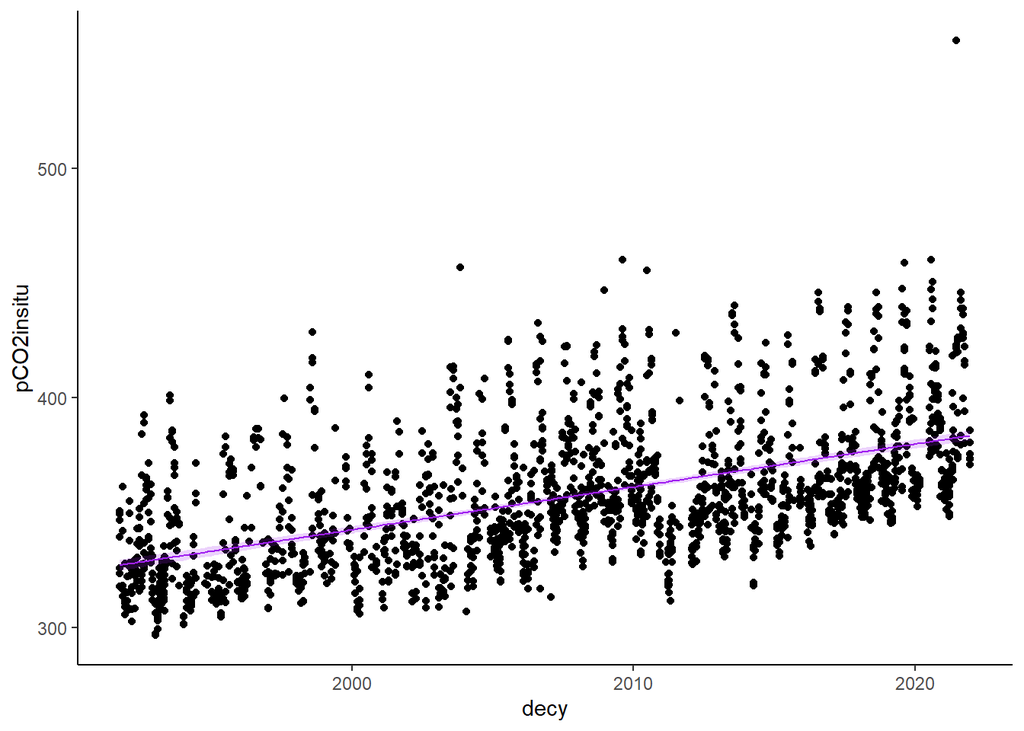

```r
bats_co2sys_surf_pred=
bats_co2sys_surf %>%
  mutate(predict(pco2_model,interval='confidence',level=0.95))

bats_co2sys_surf_pred=
cbind(bats_co2sys_surf, predict(pco2_model, interval = 'confidence',level=0.95))

bats_co2sys_surf_pred %>%
  ggplot()+
  geom_point(mapping=aes(x=decy,y=pCO2insitu))+
  geom_line(aes(decy,fit),color="purple")+
  geom_ribbon(aes(x=decy,ymin=lwr,ymax=upr),alpha=0.2,fill="purple")+
  theme_classic()
```

```r
bats_co2sys_surf$year=
  as.numeric(substr(bats_co2sys_surf$yyyymmdd,1,4))
bats_co2sys_surf$month=
  as.numeric(substr(bats_co2sys_surf$yyyymmdd,5,6))


m1=lm(pCO2insitu~decy,data=bats_co2sys_surf)
m2=lm(pCO2insitu~year+month,data=bats_co2sys_surf)
m3=lm(pCO2insitu~Temp+year+month,data=bats_co2sys_surf)
summary(m1) #r^2=0.3
```

```
##
## Call:
## lm(formula = pCO2insitu ~ decy, data = bats_co2sys_surf)
##
## Residuals:
##     Min      1Q  Median      3Q     Max
## -52.302 -18.081  -7.098  12.657 173.045
##
## Coefficients:
##               Estimate Std. Error t value Pr(>|t|)
## (Intercept) -3.396e+03  1.328e+02  -25.57   <2e-16 ***
## decy         1.869e+00  6.616e-02   28.25   <2e-16 ***
## ---
## Signif. codes:  0 '***' 0.001 '**' 0.01 '*' 0.05 '.' 0.1 ' ' 1
##
## Residual standard error: 25.75 on 1937 degrees of freedom
## Multiple R-squared:  0.2919, Adjusted R-squared:  0.2915
## F-statistic: 798.3 on 1 and 1937 DF,  p-value: < 2.2e-16
```

```r
summary(m2) #r^2=0.4
```

```
##
## Call:
## lm(formula = pCO2insitu ~ year + month, data = bats_co2sys_surf)
##
## Residuals:
##    Min     1Q Median     3Q    Max
## -49.46 -15.53  -4.68  10.71 174.97
##
## Coefficients:
##               Estimate Std. Error t value Pr(>|t|)
## (Intercept) -3.263e+03  1.215e+02  -26.84   <2e-16 ***
## year         1.793e+00  6.057e-02   29.61   <2e-16 ***
## month        3.282e+00  1.590e-01   20.64   <2e-16 ***
## ---
## Signif. codes:  0 '***' 0.001 '**' 0.01 '*' 0.05 '.' 0.1 ' ' 1
##
## Residual standard error: 23.51 on 1936 degrees of freedom
## Multiple R-squared:   0.41,  Adjusted R-squared:  0.4094
## F-statistic: 672.6 on 2 and 1936 DF,  p-value: < 2.2e-16
```

```r
summary(m3) #r^2=0.7
```

```
##
## Call:
## lm(formula = pCO2insitu ~ Temp + year + month, data = bats_co2sys_surf)
##
## Residuals:
##     Min      1Q  Median      3Q     Max
## -39.938 -10.869  -2.051   8.689 186.945
##
## Coefficients:
##               Estimate Std. Error t value Pr(>|t|)
## (Intercept) -2.965e+03  8.451e+01 -35.090   <2e-16 ***
## Temp         7.804e+00  1.706e-01  45.756   <2e-16 ***
## year         1.570e+00  4.227e-02  37.133   <2e-16 ***
## month       -2.656e-01  1.348e-01  -1.971   0.0489 *
## ---
## Signif. codes:  0 '***' 0.001 '**' 0.01 '*' 0.05 '.' 0.1 ' ' 1
##
## Residual standard error: 16.3 on 1935 degrees of freedom
## Multiple R-squared:  0.7166, Adjusted R-squared:  0.7162
## F-statistic:  1631 on 3 and 1935 DF,  p-value: < 2.2e-16
```

```r
AIC(m1,m2,m3) #use AIC to select models (lower AIC = better model)
```

```
##    df      AIC
## m1  3 18103.50
## m2  4 17751.69
## m3  5 16331.80
```

```r
bats_surf_sub=
  bats_co2sys_surf %>%
  filter(year!=-999,month!=-999,Sal1!=-999,Temp!=-999,
         `O2(1)`!=-999,`NO31`!=-999,`NO21`!=-999,
         `PO41`!=-999)

step(lm(pCO2insitu~1,data=bats_surf_sub),
     direction="forward",
     trace = 1,
     scope = ~year+month+Sal1+Temp+`O2(1)`+`NO31`+`NO21`+ `PO41`)
```

```
## Start:  AIC=12773.06
## pCO2insitu ~ 1
##
##           Df Sum of Sq     RSS   AIC
## + Temp     1    912501  816645 11372
## + year     1    453892 1275254 12206
## + `O2(1)`  1    310959 1418187 12404
## + month    1    265175 1463971 12464
## + NO21     1     36504 1692642 12735
## + Sal1     1     28247 1700899 12744
## + NO31     1      7565 1721581 12767
## <none>                 1729146 12773
## + PO41     1      1243 1727903 12774
##
## Step:  AIC=11372.23
## pCO2insitu ~ Temp
##
##           Df Sum of Sq    RSS   AIC
## + year     1    318407 498238 10450
## + NO31     1     59732 756913 11232
## + NO21     1     33649 782996 11296
## + Sal1     1     17284 799361 11334
## + PO41     1      2682 813963 11368
## + `O2(1)`  1      2106 814539 11369
## + month    1      2014 814631 11370
## <none>                 816645 11372
##
## Step:  AIC=10450.21
## pCO2insitu ~ Temp + year
##
##           Df Sum of Sq    RSS   AIC
## + NO31     1     58707 439532 10218
## + NO21     1     35825 462413 10313
## + `O2(1)`  1      5290 492948 10432
## + Sal1     1      1522 496717 10446
## + month    1      1117 497121 10448
## + PO41     1       917 497321 10449
## <none>                 498238 10450
##
## Step:  AIC=10217.77
```

[output cut: 13 more lines]

```
##           Df Sum of Sq    RSS   AIC
## + NO21     1   2229.88 432847 10193
## + month    1    714.46 434362 10200
## <none>                 435077 10201
## + `O2(1)`  1    408.85 434668 10201
## + PO41     1     38.77 435038 10203
##
## Step:  AIC=10193.11
## pCO2insitu ~ Temp + year + NO31 + Sal1 + NO21
##
##           Df Sum of Sq    RSS   AIC
## <none>                 432847 10193
## + `O2(1)`  1    395.23 432451 10193
## + month    1    298.46 432548 10194
## + PO41     1     44.88 432802 10195
```

```
##
## Call:
## lm(formula = pCO2insitu ~ Temp + year + NO31 + Sal1 + NO21, data = bats_surf_sub)
##
## Coefficients:
## (Intercept)         Temp         year         NO31         Sal1         NO21
##   -3310.874        8.698        1.501       20.670       12.525       30.404
```

```r
model_AIC=lm(pCO2insitu ~ Temp + year + NO31 + Sal1 + NO21, data = bats_surf_sub)
summary(model_AIC)
```

```
##
## Call:
## lm(formula = pCO2insitu ~ Temp + year + NO31 + Sal1 + NO21, data = bats_surf_sub)
##
## Residuals:
##     Min      1Q  Median      3Q     Max
## -39.910  -9.764  -1.305   8.262 191.189
##
## Coefficients:
##               Estimate Std. Error t value Pr(>|t|)
## (Intercept) -3.311e+03  1.204e+02 -27.490  < 2e-16 ***
## Temp         8.698e+00  1.527e-01  56.950  < 2e-16 ***
## year         1.501e+00  4.199e-02  35.742  < 2e-16 ***
## NO31         2.067e+01  1.970e+00  10.493  < 2e-16 ***
## Sal1         1.253e+01  2.732e+00   4.584 4.86e-06 ***
## NO21         3.040e+01  9.812e+00   3.099  0.00197 **
## ---
## Signif. codes:  0 '***' 0.001 '**' 0.01 '*' 0.05 '.' 0.1 ' ' 1
##
## Residual standard error: 15.24 on 1864 degrees of freedom
## Multiple R-squared:  0.7497, Adjusted R-squared:  0.749
## F-statistic:  1116 on 5 and 1864 DF,  p-value: < 2.2e-16
```

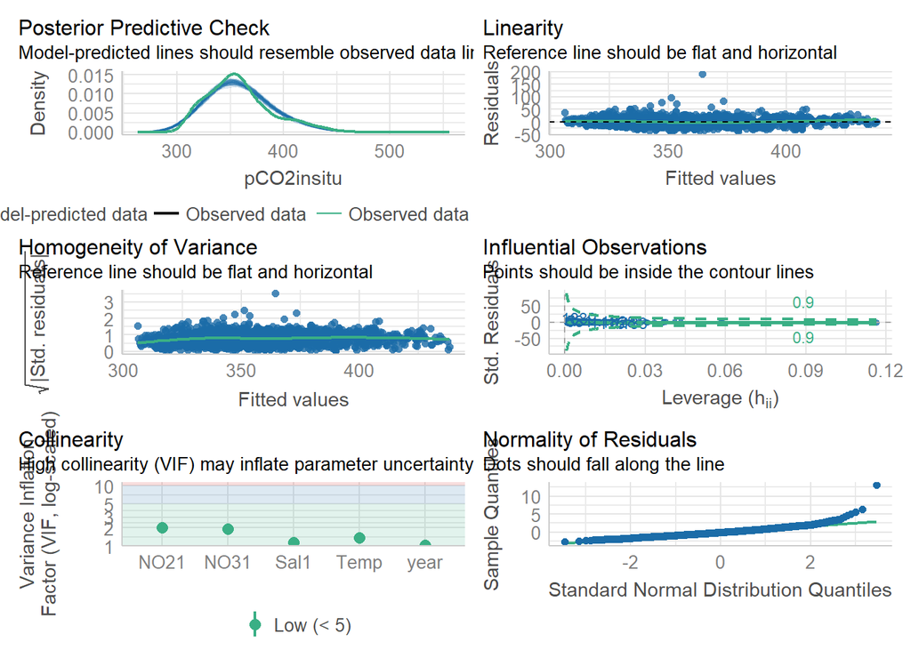

```r
check_model(model_AIC)
```

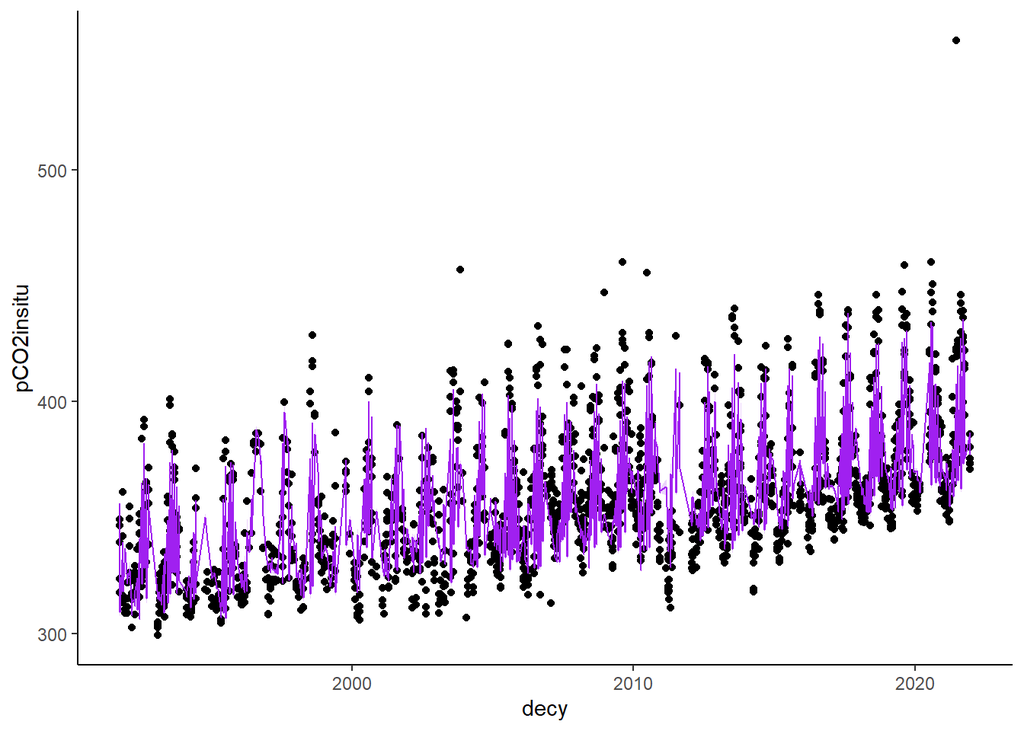

```r
bats_surf_sub_pred=
  cbind(bats_surf_sub,
        predict(model_AIC, interval = 'confidence',level=0.95))

#add prediction line to ggplot
bats_surf_sub_pred %>%
  ggplot()+
  geom_point(mapping=aes(x=decy,y=pCO2insitu))+
  geom_line(aes(decy,fit),color="purple")+
  geom_ribbon(aes(x=decy,ymin=lwr,ymax=upr),alpha=0.2,fill="purple")+
  theme_classic()
```